# The Elements of Statistical Learning - Hastie

## Chapter 8: Model Inference and Averaging

### 8.5 Expectation Maximization Algorithm

### Maximum Likelihood Estimation for Mixture Models

Finding the maximum likelihood can prove to be more difficult for models with more than one component. As described in the section, below is an implementation of an Expectation Maximization algorithm to model maximum likelihood estimation given an example of a model with two components. Before discussion of the model and algorithm, first we import the necessary Python libraries.

```python
import numpy as np
from scipy.stats import norm
import matplotlib.pyplot as plt
```

Next, we use the same data provided on page 273. We also store the number of data points, and plot the distribution of the data points to get an idea of the underlying density.

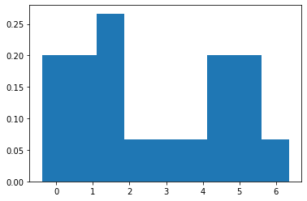

```python
data = np.array([-0.39, 0.12, 0.94, 1.67, 1.76, 2.44, 3.72, 4.28, 4.92, 5.53,
                 0.06, 0.48, 1.01, 1.68, 1.80, 3.25, 4.12, 4.60, 5.28, 6.22])
N = len(data)
ax = plt.hist(data, bins=np.arange(min(data), max(data) + 0.75, 0.75), density=True)
```

As described in the book, a reasonable observation of the distribution of the data, given its two peaks, is that it can be modeled as the combination of two normal distributions (8.36):

$$ Y \sim (1-\Delta) N(\mu_1, \sigma_1^2) + \Delta N(\mu_2, \sigma_2^2)$$

Where $\Delta$ is either zero or one. Thus, and observation of $Y$ either comes from the first or second normal distribution based on the value of $\Delta$. The probability that $\Delta_i = 1$ is denoted as $\pi$. Our goal is to find the parameters $\bar{\mu}, \bar{\sigma^2}, \pi$ that maximize the log-likelihood function of $Y$. As described in the book, finding the maximum likelihood estimates for $\bar{\mu}$ and $\bar{\sigma}$ is easy for each individual component. Thus, we can use the fact that $\Delta \in \{0,1\}$ to set a guess of the frequency $\Delta_i = 1$ as $\gamma_i = $ probablity $\Delta_i = 1$ given our estimats of $\bar{\mu_i}, \bar{\sigma_i^2}$ and $\pi$. The idea will then be to iteratively maximize the log-likelihood by updating each parameter.

The psuedocode of the algorithm is on page 275.

The first step is to set reasonable initial estimates for the parameters we are estimating. The text suggests the sample variance for both variance estiamtes, two random data points for the mean estimates, and for mixing probability $\pi = \frac{1}{2}$.

```python
var = sum((data - data.mean()) ** 2) / N * np.array([1, 1])
mu = data[np.random.choice(N, 2, replace=False)]
pi = 0.5
```

The next step is implementing the iterative optimization process of the algorithm. This consists of first computing the expectation of each $\gamma_i$ as described above, and using the updated $\gamma$ to recalculate the sample means and variances weighted by the expectation of $\Delta$ modeled from $\gamma$ in the maximization step. Once the stopping condition is met, the parameters are kept as our maximum likelihood estimates.

```python
cnt = 1
while 1:
    print("Iteration " + str(cnt) + ": pi ~= " + str(round(pi,3)))
    gamma = np.zeros(N)

    #Expectation Step
    for i in range(N):
        gamma[i] = ( (pi * norm.pdf(data[i], mu[1], np.sqrt(var[1]))) /
                     ((1 - pi) * norm.pdf(data[i], mu[0], np.sqrt(var[0])) + pi * norm.pdf(data[i], mu[1], np.sqrt(var[1]))) )

    #Maximization Step
    mu[0] = sum((1-gamma)*data) / sum(1-gamma)
    mu[1] = sum(gamma*data) / sum(gamma)
    var[0] = sum((1-gamma)*(data-mu[0])**2) / sum(1-gamma)
    var[1] = sum(gamma*(data-mu[1])**2) / sum(gamma)
    lastpi = pi
    pi = sum(gamma) / N

    #Stopping Condition
    if abs(pi - lastpi) < 10e-4:
        break
    cnt += 1

print(("mu_1 = " + str(round(mu[0],3)) + ", mu_2 = " + str(round(mu[1],3)) + "\n" +
       "var_1 = " + str(round(var[0],3)) + ", var_2 = " + str(round(var[1],3))))
```

```
Iteration 1: pi ~= 0.5
Iteration 2: pi ~= 0.324
Iteration 3: pi ~= 0.339
Iteration 4: pi ~= 0.355
Iteration 5: pi ~= 0.372
Iteration 6: pi ~= 0.387
Iteration 7: pi ~= 0.4
Iteration 8: pi ~= 0.412
Iteration 9: pi ~= 0.421
Iteration 10: pi ~= 0.429
Iteration 11: pi ~= 0.434
Iteration 12: pi ~= 0.438
Iteration 13: pi ~= 0.44
Iteration 14: pi ~= 0.442
Iteration 15: pi ~= 0.443
mu_1 = 1.088, mu_2 = 4.662
var_1 = 0.82, var_2 = 0.811
```

To visualize how our parameters fit the underlying data and bi-modal distribution assumption, we can use the derived probability density function to plot it against the distribution of the given data. First, the pdf is simply given by:

$$g_Y(x) = (1-\Delta) f(x, \mu_1, \sigma_1) + \Delta f(x, \mu_2, \sigma_2)$$

Where $f$ is the normal pdf, given as $f(x, \pi, \sigma) = \frac{1}{\sigma\sqrt{2\pi}}e^{-\frac{1}{2}(\frac{x-\mu}{\sigma})^2}$.

```python
def g(x, pi, mu, var):
    return (1-pi)*norm.pdf(x, mu[0], np.sqrt(var[0])) + (pi)*norm.pdf(x, mu[1], np.sqrt(var[1]))
```

Now we can plot our pdf versus the given data, and we see that our estimates of the parameters provided a good estimate of the data given. With our derived pdf, we can be more confident in the underlying distribution of sampled data.

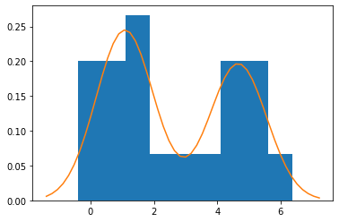

```python
ax = plt.hist(data, bins=np.arange(min(data), max(data) + 0.75, 0.75), density=True)
x = np.linspace(min(data)-1,max(data)+1)
y = g(x, pi, mu, var)
ax = plt.plot(x,y)
```

### Generalizing the EM Algorithm for M Guassian Components

In order to generalize the above algorithm for $M$ normal components, first we need to generalize the assumption of the underlying distribution. \begin{align} &\sum_i^M \Delta_i = 1, \; \Delta_i \in \{0,1\} \; \forall i \\ &P(\Delta_i = 1) = \pi_i, \; \forall i \\ &Y \sim \sum_i^M \Delta_i N(\mu_i, \sigma_i^2) \end{align} The same initial guesses will be used, with the change of $\pi_i = \frac{1}{M}$ for all $i$ to ensure $\sum_{i=1}^M \pi_i = 1$. The function below takes the data as an input, along with the number of mixtures we are assuming $M$.

```python
def Expectation_Maximization(data, M):

    N = len(data)

    var = sum((data - data.mean()) ** 2) / N * np.array([1 for i in range(M)])
    mu = data[np.random.choice(N, M, replace=False)]
    pi = np.array([1/M for i in range(M)])

    cnt = 1
    while 1:
        if cnt % 10 == 0 or cnt == 1:
            print("Iteration " + str(cnt) + ": pi ~= ")
            print(pi)

        #Expectation Step
        gamma = np.zeros((N,M))
        for i in range(N):
            for j in range(M):
                gamma[i,j] = ( pi[j]*norm.pdf(data[i], mu[j], np.sqrt(var[j])) /
                             sum(pi*norm.pdf(data[i], mu, np.sqrt(var))) )

        #Maximization Step
        lastpi = pi
        for j in range(M):
            mu[j] = sum(gamma[:,j]*data) / sum(gamma[:,j])
            var[j] = sum(gamma[:,j]*(data-mu[j])**2) / sum(gamma[:,j])
            pi[j] = sum(gamma[:,j]) / N

        if cnt > 50:
            break
        cnt += 1

    return (mu, var, pi)
```

We also need an updated function that calculates the density function given parameters of any length.

```python
def g_general(x, pi, mu, var):
    return sum(pi*norm.pdf(x, mu, np.sqrt(var)))
```

Now we can generate some data split from $M$ normal distributions with random parameters. We can then run the algorithm, and see how well the estimation fits the underlying data. The below generates data for $M =$ 3, 4, and 5, runs the model, and plots the results.

```
Iteration 1: pi ~=
[0.33333333 0.33333333 0.33333333]
Iteration 10: pi ~=
[0.26058792 0.26584351 0.47356857]
Iteration 20: pi ~=
[0.3337524  0.33296741 0.3332802 ]
Iteration 30: pi ~=
[0.33379038 0.33302006 0.33318957]
Iteration 40: pi ~=
[0.33379038 0.33302006 0.33318957]
Iteration 50: pi ~=
[0.33379038 0.33302006 0.33318957]
Iteration 1: pi ~=
[0.25 0.25 0.25 0.25]
Iteration 10: pi ~=
[0.23874277 0.30376927 0.23864693 0.21884103]
Iteration 20: pi ~=
[0.24903751 0.31715653 0.24896126 0.18484469]
Iteration 30: pi ~=
[0.25543106 0.32372627 0.25538726 0.1654554 ]
Iteration 40: pi ~=
[0.26012394 0.32617745 0.26012462 0.15357398]
Iteration 50: pi ~=
[0.26381286 0.32548522 0.26387586 0.14682606]
Iteration 1: pi ~=
[0.2 0.2 0.2 0.2 0.2]
Iteration 10: pi ~=
[0.21509217 0.15464584 0.19313327 0.13407613 0.30305258]
Iteration 20: pi ~=
[0.19263128 0.13104063 0.27044338 0.08248047 0.32340423]
Iteration 30: pi ~=
[0.14286381 0.11446731 0.32723288 0.05764596 0.35779004]
Iteration 40: pi ~=
[0.02835949 0.19833849 0.33049362 0.06953179 0.37327661]
Iteration 50: pi ~=
[0.04617789 0.19940908 0.27886265 0.12113643 0.35441394]
```

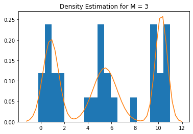

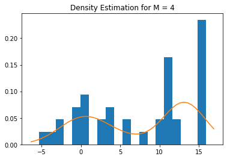

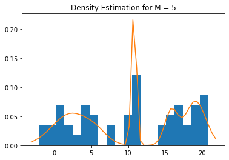

```python
for M in range(3,6):
    data = np.array([])
    for i in range(M):
        mu = 5*i + np.random.rand()
        var = 3*np.random.rand()
        data = np.append(data, np.random.normal(mu, var, 10))
    mu, var, pi = Expectation_Maximization(data, M)
    ax = plt.figure()
    ax = plt.hist(data, bins = 20, density=True)
    x = np.linspace(min(data)-1,max(data)+1)
    y = np.array([g_general(xi, pi, mu, var) for xi in x])
    ax = plt.plot(x,y)
    ax = plt.title("Density Estimation for M = " + str(M))
```